# (Ford GoBike)

## Dataset Overview

> This data set includes information about people who rented bike of ford Gobike system at San-Francisco .It include only thr recordes of feburary of 2019.

```python
# import all packages and set plots to be embedded inline
import numpy as np
import pandas as pd
import matplotlib.pyplot as plt
import seaborn as sb

%matplotlib inline

# suppress warnings from final output
import warnings
warnings.simplefilter("ignore")
```

```python
def chart_name(x ,y ,t):
    plt.title(x, fontsize = 20)
    plt.xlabel(y, fontsize = 15)
    plt.ylabel(t, fontsize = 15)
    plt.show();
```

```python
# load in the dataset into a pandas dataframe
df = pd.read_csv('Bike.csv')
```

> Note that the above cells have been set as "Skip"-type slides. That means that when the notebook is rendered as http slides, those cells won't show up.

## What is the type of our users?

It is about of 90% of users are Subscriber and 10% are Customer .

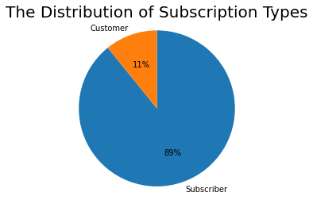

```python
# plot the piechart to show the type of user
sorted_counts = df['user_type'].value_counts()
plt.pie(sorted_counts, labels = sorted_counts.index, autopct='%1.0f%%', startangle=90, counterclock = False)
plt.title("The Distribution of Subscription Types", fontsize=20)
plt.axis('square');
```

## What is the gender of our users?

The majurty of our users are Male .

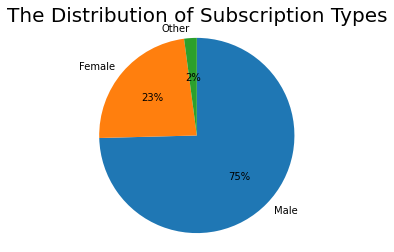

```python
# plot the piechart to show the type of user
sorted_counts = df['member_gender'].value_counts()
plt.pie(sorted_counts, labels = sorted_counts.index, autopct='%1.0f%%', startangle=90, counterclock = False)
plt.title("The Distribution of Subscription Types", fontsize=20)
plt.axis('square');
```

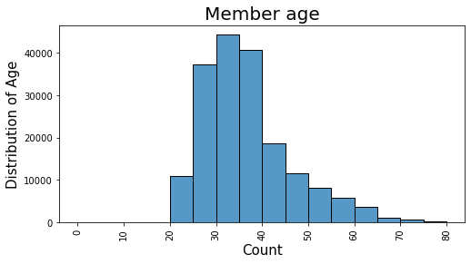

```python
# Distribution of Age
base_color = sb.color_palette()[0]
plt.figure(figsize = (8,4))

bins = np.arange(0, df['member_age'].max()+5, 5)
sb.histplot(data=df, x='member_age', color=base_color, bins = bins)
plt.xticks(rotation=90)
chart_name('Member age','Count',"Distribution of Age")
```

## What is the Crowded days of Week ?

All weekday are crowded instead of saturday and sunday ,as they are the weekend .

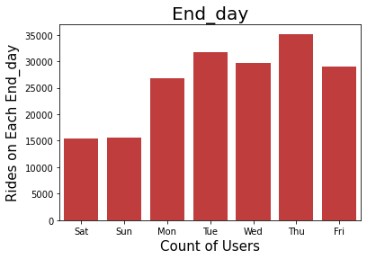

```python
base_color = sb.color_palette()[3]
order = ['Sat', 'Sun','Mon', 'Tue', 'Wed', 'Thu', 'Fri']
sb.countplot(data = df, x = 'end_day', order = order, color = base_color)

chart_name('End_day','Count of Users','Rides on Each End_day')
```

## what is the days that users ride for long time?

Althoug the saturday and sunday have less user,but this days have long trips duration.

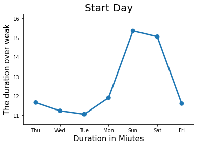

```python
# plot the point plot of Start day
sb.pointplot(data=df, x='start_day', y='duration_min', errwidth=0)

chart_name('Start Day' , 'Duration in Miutes' , 'The duration over weak')
```

## Who ride for long time of our users by type?

The Avg of customer is about 25 minutes,but the customer Avg is about 11 minutes per week.

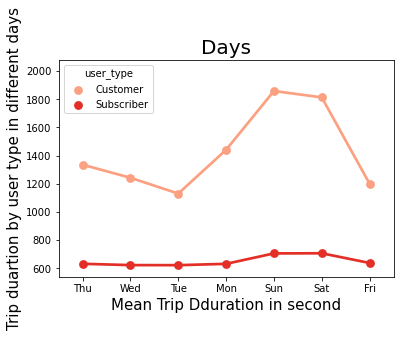

```python
sb.pointplot(data = df, x = 'start_day', y = 'duration_sec', hue = 'user_type', palette = 'Reds', errwidth=0)

chart_name('Days','Mean Trip Dduration in second','Trip duartion by user type in different days')
```

## Who ride for long time of our users by Gender ?

The Avg of Female rides over weak are greater than Male .

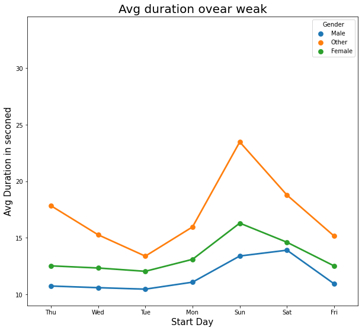

```python
# plot the point plot of Duration vs gender


plt.figure(figsize=(10,9))
sb.pointplot(data=df, x='start_day', y='duration_min', hue='member_gender', errwidth=0)

plt.legend(title='Gender')
chart_name('Avg duration ovear weak'  ,'Start Day','Avg Duration in seconed')
```

> Once you're ready to finish your presentation, check your output by using nbconvert to export the notebook and set up a server for the slides. From the terminal or command line, use the following expression:

> > `jupyter nbconvert <file_name>.ipynb --to slides --post serve --template output_toggle`

> This should open a tab in your web browser where you can scroll through your presentation. Sub-slides can be accessed by pressing 'down' when viewing its parent slide. Make sure you remove all of the quote-formatted guide notes like this one before you finish your presentation!

```python
!jupyter nbconvert slide_deck_bike.ipynb --to slides --post serve --no-input --no-prompt
```

[output not shown]